# **SMALL-BASKET***

# 1.LOCATION dataset

```python
import pandas as pd
import numpy as np
import matplotlib.pyplot as plt
import seaborn as sns
%matplotlib inline
```

```python
import os
os.getcwd()
```

```
'/content'
```

```python
os.chdir("/content/drive/My Drive/PHD final")
```

```python
data_loc=pd.read_csv("./location_details (1).csv")
```

```python
data_loc.nunique()
```

```
location_id    54
city           22
state          13
type            5
cluster        17
dtype: int64
```

```python
data_loc["location_id"]=data_loc["location_id"].str.split("_",expand=True)[1]
```

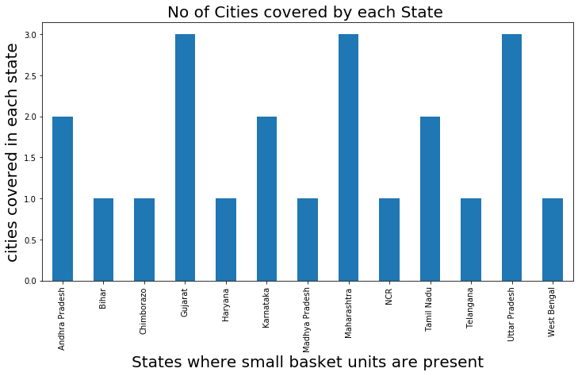

```python
plt.figure(figsize=(12,6))
data_loc.groupby("state")["city"].nunique().plot.bar()
plt.xlabel("States where small basket units are present",fontsize=20)
plt.ylabel("cities covered in each state",fontsize=20)
plt.title("No of Cities covered by each State ",fontsize=20)
plt.show()# plot
```

### * In maharashtra,U.P,Gujarat they have covered more number of cities(3) compared to other states.

## *they have kept units in almost all metropolitan cities and cities having population more than 1.3 millionpopulation

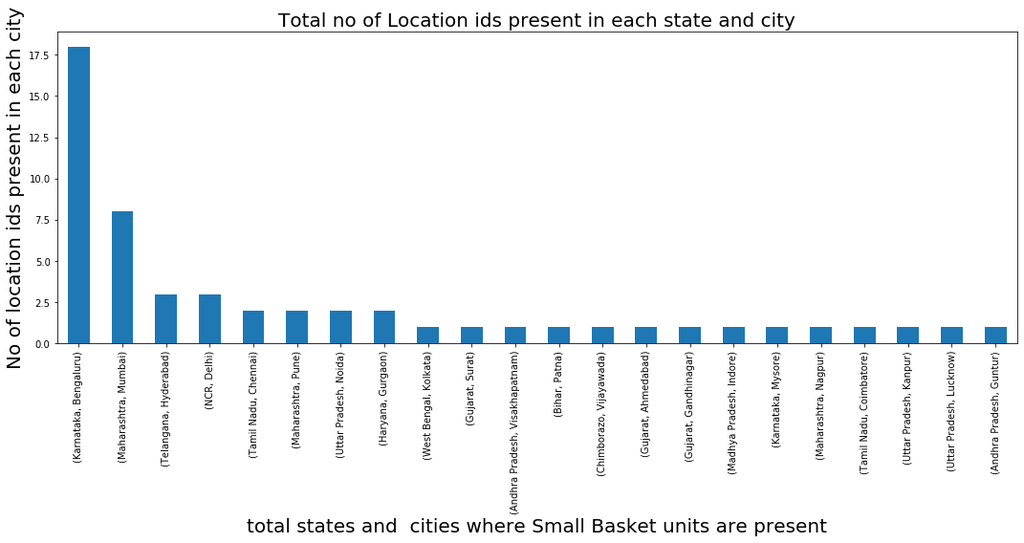

```python
import math
plt.figure(figsize=(18,6))
data_loc.groupby(["state","city"])["location_id"].count().sort_values(ascending=False).plot.bar()
plt.xlabel("total states and  cities where Small Basket units are present",fontsize=20)
plt.ylabel("No of location ids present in each city",fontsize=20)
plt.title("Total no of Location ids present in each state and city",fontsize=20)
plt.show()
```

## *in bangalore city they have covered only 2 cities but they more no of location_id(18)

## * no other state is having that many location id's when compared to U.P and maharastra no of cities present karnataka are very less they why......?

## * bangalore is havingtotal IT companies of 67,000/- that means people working there will be almost all over INDIA and from other countries toooo.

## *different people having different food habits more over every one cant go outside and buy so they prefer online

## *mumbai is business capital but not IT compared to bangalore so it is given less importance.

## * IT going areas are best for SMALL basket to start new units and next business developing ares

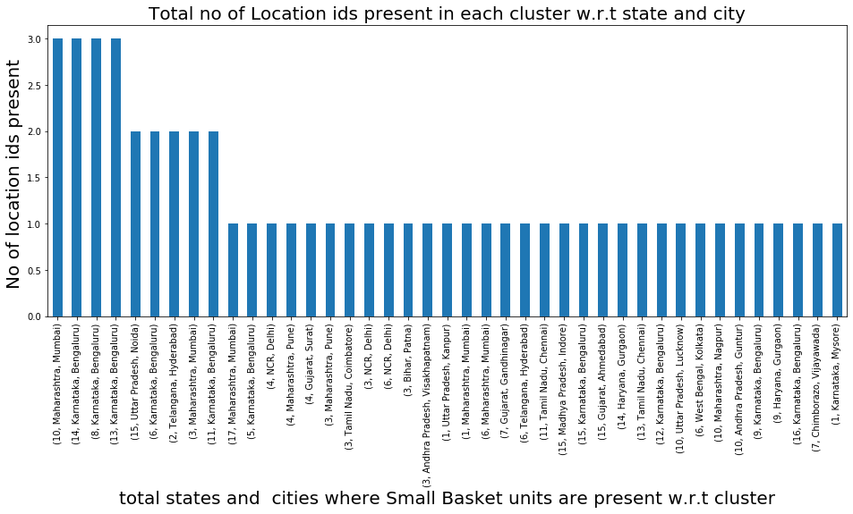

```python
import math
plt.figure(figsize=(16,6))
data_loc.groupby(["cluster","state","city"])["location_id"].count().sort_values(ascending=False).plot.bar()
plt.xlabel("total states and  cities where Small Basket units are present w.r.t cluster",fontsize=20)
plt.ylabel("No of location ids present ",fontsize=20)
plt.title("Total no of Location ids present in each cluster w.r.t state and city",fontsize=20)
plt.show()
```

# *cluster

```python
data_loc.groupby('cluster')["state"].unique()
```

```
cluster
1               [Maharashtra, Uttar Pradesh, Karnataka]
2                                           [Telangana]
3     [NCR, Maharashtra, Tamil Nadu, Andhra Pradesh,...
4                           [NCR, Gujarat, Maharashtra]
5                                           [Karnataka]
6     [Karnataka, West Bengal, NCR, Maharashtra, Tel...
7                                 [Chimborazo, Gujarat]
8                                           [Karnataka]
9                                  [Karnataka, Haryana]
10         [Maharashtra, Andhra Pradesh, Uttar Pradesh]
11                              [Karnataka, Tamil Nadu]
12                                          [Karnataka]
13                              [Karnataka, Tamil Nadu]
14                                 [Karnataka, Haryana]
15    [Karnataka, Uttar Pradesh, Gujarat, Madhya Pra...
16                                          [Karnataka]
17                                        [Maharashtra]
Name: state, dtype: object
```

## * if we group by cluster, cluster is a group

### * here cluster is a group of cities but they are not unique cities in each cluster are repeating and more over we cannot find any similarities it is a combination of both north and south places

```python
data_loc.groupby('cluster')['location_id'].unique()
```

```
cluster
1                     [24, 25, 27]
2                         [37, 42]
3     [16, 30, 32, 33, 35, 40, 54]
4                      [5, 38, 41]
5                             [44]
6          [9, 11, 20, 21, 34, 39]
7                         [14, 22]
8                        [3, 7, 8]
9                          [4, 23]
10        [26, 28, 29, 31, 36, 43]
11                    [45, 49, 52]
12                            [17]
13                   [1, 2, 6, 53]
14                [46, 47, 48, 50]
15            [10, 12, 13, 15, 19]
16                            [18]
17                            [51]
Name: location_id, dtype: object
```

## * location _id are not repeated that means cluster is a group of location_id of different states

## * if each cluster is handled by a particular person so that business people can get some sort of information from all the statesfrom different people and get to one conclusion.

# **type

```python
data_loc["type"].unique()
```

```
array(['D', 'B', 'C', 'E', 'A'], dtype=object)
```

```python
c=data_loc.groupby(["state","city"])["type"].unique() # i want unique types also
```

```python
pd.DataFrame(c)
```

| state | city | type |
| --- | --- | --- |
| Andhra Pradesh | Guntur | [E] |
|  | Visakhapatnam | [C] |
| Bihar | Patna | [C] |
| Chimborazo | Vijayawada | [C] |
| Gujarat | Ahmedabad | [C] |
|  | Gandhinagar | [C] |
|  | Surat | [D] |
| Haryana | Gurgaon | [D, A] |
| Karnataka | Bengaluru | [D, B, C, A] |
|  | Mysore | [D] |
| Madhya Pradesh | Indore | [C] |
| Maharashtra | Mumbai | [D, E, C, B, A] |
|  | Nagpur | [B] |
|  | Pune | [C, D] |
| NCR | Delhi | [D, C, B] |
| Tamil Nadu | Chennai | [A, D] |
|  | Coimbatore | [C] |
| Telangana | Hyderabad | [D, B] |
| Uttar Pradesh | Kanpur | [D] |
|  | Lucknow | [E] |
|  | Noida | [C] |
| West Bengal | Kolkata | [B] |

### * from avove we can say that mumbai is having all type of classes and bangalore is having 4 type of classes

### * type A is present in only bangalore,mumbai,chennai,gurgon that means it is of high-level cities.

### *that means "type" might be items belonging to particular type or particular sections some brands and some items can be found only in big malls of costly...... in order of costly type to normal type

# * 2nd dataset gives the information of "ITEM-DETAILS" present in small basket

```python
data_item=pd.read_csv("./item_details (1).csv")
```

```python
data_item.nunique()
```

```
item_id             4100
category_of_item      30
class                337
perishable             2
dtype: int64
```

## * here we are having different categories and each category is having diffrent classes and each class is having diffrent item_ids

```python
data_item.item_id=data_item.item_id.str.split("_",expand=True)[1]
```

```python
data_item["class"]=data_item["class"].str.split("_",expand=True)[1]
```

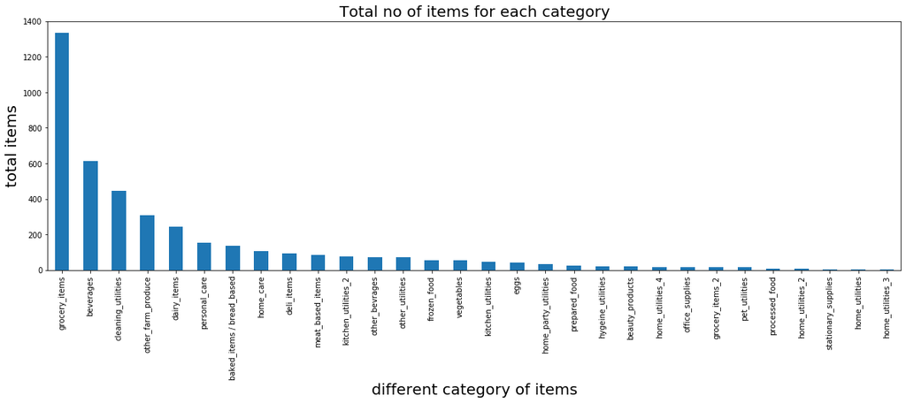

```python
plt.figure(figsize=(20,6))
data_item.groupby("category_of_item")["item_id"].nunique().sort_values(ascending=False).plot.bar()
plt.xlabel("different category of items",fontsize=20)
plt.ylabel("total items",fontsize=20)
plt.title("Total no of items for each category",fontsize=20)
plt.show()#ploting
```

## *beverages are having 22 classes and have 600 item_ids

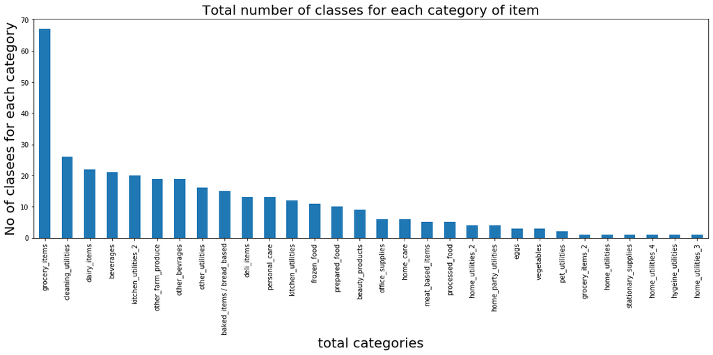

```python
plt.figure(figsize=(18,6))
data_item.groupby("category_of_item")["class"].nunique().sort_values(ascending=False).plot.bar()
plt.xlabel("total categories",fontsize=20)
plt.ylabel("No of clasees for each category",fontsize=20)
plt.title("Total number of classes for each category of item",fontsize=20)
plt.show()#ploting
```

```python
data_item.perishable.nunique()
```

```
2
```

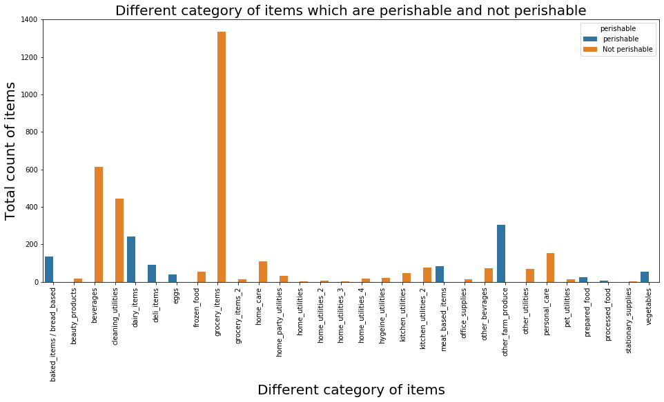

```python
plt.figure(figsize=(16,7))
df = data_item.groupby(['category_of_item','perishable']).agg({'item_id':'count'}).reset_index()
df.perishable=df.perishable.map({0:'Not perishable',1:'perishable'})
sns.barplot(data=df,x='category_of_item',y='item_id',hue='perishable')
plt.xticks(rotation=90)
plt.xlabel("Different category of items",fontsize=20)
plt.ylabel("Total count of items",fontsize=20)
plt.title("Different category of items which are perishable and not perishable",fontsize=20)
plt.show()
```

### * grocery items are having high number of non-perishable items that means they can put stock of them. same as beverages and cleaning_utilities

### * farm produces items are perishable so they must put very less stock.must change at regural intervals.